# Composition of Unemployment by Reason

CPS Table A-11 · Post-1994 Redesign · Six-Way Decomposition

Published

April 2, 2026

## Overview

The headline unemployment rate tells you *how many* people are unemployed, but not *why*. A rising rate driven by permanent layoffs signals a very different economy than one driven by temporary furloughs, voluntary quits, or new graduates entering the job market for the first time.

The Bureau of Labor Statistics classifies every unemployed person into one of six mutually exclusive categories based on their reason for unemployment: **temporary layoffs** (expecting recall), **permanent job losers** (no recall expected), **completed temporary jobs**, **job leavers** (quit voluntarily), **reentrants** (returning to the labor force after a period out), and **new entrants** (searching for their first job ever). These six groups sum to total unemployment. We also aggregate them into two broader groups — **job separations** (the first four) and **labor force entry** (reentrants + new entrants) — to isolate the demand-side from the supply-side channel.

This report decomposes the unemployment rate along these dimensions to answer a central question: **what is driving changes in unemployment, and how has the composition shifted over time?** Each component’s level divided by the civilian labor force gives its contribution to the total unemployment rate; stacking these contributions reconstructs the headline number. The distinction matters for policy: a surge in permanent job losers calls for countercyclical intervention, a spike in temporary layoffs may signal a shock firms expect to reverse, rising job leavers can indicate labor market confidence, and a rise in new entrants may reflect demographic shifts or an expanding economy drawing in first-time workers. By tracking both the rate contributions and the period-over-period changes of each component, we can distinguish between cyclical deterioration, structural shifts, and signs of labor market strength.

```r
library(tidyverse)
library(arrow)
library(here)
library(ggsci)      # for scale_*_jco()
library(scales)
library(gt)
library(lubridate)
library(patchwork)

here::i_am("unemployment_decomposition.qmd")
read_final_parquet <- function(filename) {
  path <- here("data", "final", filename)
  if (!file.exists(path)) {
    stop("Missing derived panel: ", path, ". Run 'Rscript build_panels.R'.")
  }
  arrow::read_parquet(path) |>
    as_tibble()
}

# ── FRED API key ─────────────────────────────────────────────────────────
# Set your FRED API key. Get one free at https://fred.stlouisfed.org/docs/api/api_key.html
# Uncomment and set below, or use Sys.setenv() in your .Renviron

# ── Theme ────────────────────────────────────────────────────────────────
theme_report <- theme_minimal(base_size = 11, base_family = "sans") +
  theme(
    plot.title = element_text(face = "bold", size = 13),
    plot.subtitle = element_text(color = "grey50", size = 9),
    plot.caption = element_text(color = "grey60", size = 7, hjust = 0),
    panel.grid.minor = element_blank(),
    panel.grid.major.x = element_blank(),
    axis.title = element_text(size = 9, color = "grey40"),
    axis.text = element_text(size = 8, color = "grey50"),
    legend.position = "top",
    legend.text = element_text(size = 8),
    legend.title = element_blank()
  )

theme_set(theme_report)

# ── Palettes ─────────────────────────────────────────────────────────────
# 6-color palette for the six-way cause decomposition
cause_cols <- pal_jco()(6)
names(cause_cols) <- c("Temporary Layoff", "Permanent Job Losers",
                       "Completed Temp Job", "Job Leavers",
                       "Reentrants", "New Entrants")

# 2-color palette for two-group decomposition
group_cols <- c("Job Separations" = "#0073C2", "Labor Force Entry" = "#EFC000")

# ── NBER recession dates (post-1994) ────────────────────────────────────
recessions <- tibble(
  start = as.Date(c("2001-03-01", "2007-12-01", "2020-02-01")),
  end   = as.Date(c("2001-11-01", "2009-06-01", "2020-04-01"))
)

add_recessions <- function(p, alpha = 0.08) {
  p + annotate("rect",
    xmin = recessions$start, xmax = recessions$end,
    ymin = -Inf, ymax = Inf,
    fill = "grey40", alpha = alpha
  )
}
```

```r
cause_order = c("Temporary Layoff", "Permanent Job Losers", "Completed Temp Job",
                 "Job Leavers", "Reentrants", "New Entrants")

df6 = read_final_parquet("unemployment_fred_monthly.parquet")

df6_long = df6 |>
  select(date, all_of(paste0(cause_order, "_rate"))) |>
  pivot_longer(-date, names_to = "cause", values_to = "rate") |>
  mutate(
    cause = str_remove(cause, "_rate"),
    cause = factor(cause, levels = cause_order)
  )

group_order = c("Job Separations", "Labor Force Entry")

df2 = df6

df2_long = df2 |>
  select(date, `Job Separations_rate`, `Labor Force Entry_rate`) |>
  pivot_longer(-date, names_to = "group", values_to = "rate") |>
  mutate(
    group = str_remove(group, "_rate"),
    group = factor(group, levels = group_order)
  )
```

```r
df4_nat = read_final_parquet("unemployment_fourway_nativity.parquet")
df4_cit = read_final_parquet("unemployment_fourway_citizenship.parquet")
```

```r
fourway_nat_order = c("Foreign Born × Separations", "Native Born × Separations",
                        "Foreign Born × Entry", "Native Born × Entry")
fourway_nat_cols = c(
  "Foreign Born × Separations" = "#003f7f",
  "Native Born × Separations"  = "#66b2ff",
  "Foreign Born × Entry"       = "#b8860b",
  "Native Born × Entry"        = "#ffe680"
)
fourway_cit_order = c("Noncitizen × Separations", "Citizen × Separations",
                        "Noncitizen × Entry", "Citizen × Entry")
fourway_cit_cols = c(
  "Noncitizen × Separations" = "#003f7f",
  "Citizen × Separations"    = "#66b2ff",
  "Noncitizen × Entry"       = "#b8860b",
  "Citizen × Entry"          = "#ffe680"
)

df4_nat_long = df4_nat |>
  select(date, all_of(paste0(fourway_nat_order, "_rate")), urate) |>
  pivot_longer(-c(date, urate), names_to = "group", values_to = "rate") |>
  mutate(group = str_remove(group, "_rate") |> factor(levels = fourway_nat_order))

df4_cit_long = df4_cit |>
  select(date, all_of(paste0(fourway_cit_order, "_rate")), urate) |>
  pivot_longer(-c(date, urate), names_to = "group", values_to = "rate") |>
  mutate(group = str_remove(group, "_rate") |> factor(levels = fourway_cit_order))

df4_nat_chg = df4_nat |>
  arrange(date) |>
  mutate(
    across(all_of(paste0(fourway_nat_order, "_rate")),
           \(x) x - lag(x, 12), .names = "{.col}_chg"),
    urate_chg = urate - lag(urate, 12)
  ) |>
  filter(!is.na(urate_chg))

df4_nat_chg_long = df4_nat_chg |>
  select(date, ends_with("_rate_chg")) |>
  pivot_longer(-date, names_to = "group", values_to = "chg") |>
  mutate(group = str_remove(group, "_rate_chg") |> factor(levels = fourway_nat_order))

df4_cit_chg = df4_cit |>
  arrange(date) |>
  mutate(
    across(all_of(paste0(fourway_cit_order, "_rate")),
           \(x) x - lag(x, 12), .names = "{.col}_chg"),
    urate_chg = urate - lag(urate, 12)
  ) |>
  filter(!is.na(urate_chg))

df4_cit_chg_long = df4_cit_chg |>
  select(date, ends_with("_rate_chg")) |>
  pivot_longer(-date, names_to = "group", values_to = "chg") |>
  mutate(group = str_remove(group, "_rate_chg") |> factor(levels = fourway_cit_order))

df4_nat_chg_recent      = df4_nat_chg      |> filter(date >= as.Date("2023-01-01"))
df4_nat_chg_recent_long = df4_nat_chg_long |> filter(date >= as.Date("2023-01-01"))
df4_cit_chg_recent      = df4_cit_chg      |> filter(date >= as.Date("2023-01-01"))
df4_cit_chg_recent_long = df4_cit_chg_long |> filter(date >= as.Date("2023-01-01"))
```

## 1. Unemployment Rate by Cause (1994–Present)

**Six-Way**

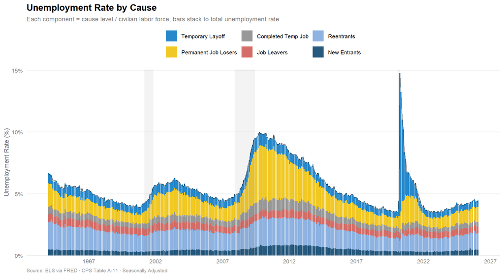

Figure 1: Unemployment rate decomposed by cause (six-way). Bars stack to total unemployment rate.

```r
p_cause <- df6_long |>
  ggplot(aes(x = date, y = rate, fill = cause)) +
  geom_col(alpha = 0.85, width = 28, position = "stack") +
  geom_line(
    data = df6, aes(x = date, y = urate, fill = NULL),
    color = "black", linewidth = 0.4, alpha = 0.5
  ) +
  scale_fill_manual(values = cause_cols) +
  scale_y_continuous(labels = \(x) paste0(x, "%"),
                     expand = expansion(mult = c(0, 0.02))) +
  scale_x_date(date_breaks = "5 years", date_labels = "%Y") +
  labs(
    title = "Unemployment Rate by Cause",
    subtitle = "Each component = cause level / civilian labor force; bars stack to total unemployment rate",
    y = "Unemployment Rate (%)", x = NULL,
    caption = "Source: BLS via FRED · CPS Table A-11 · Seasonally Adjusted"
  )

add_recessions(p_cause)
```

**Two-Group**

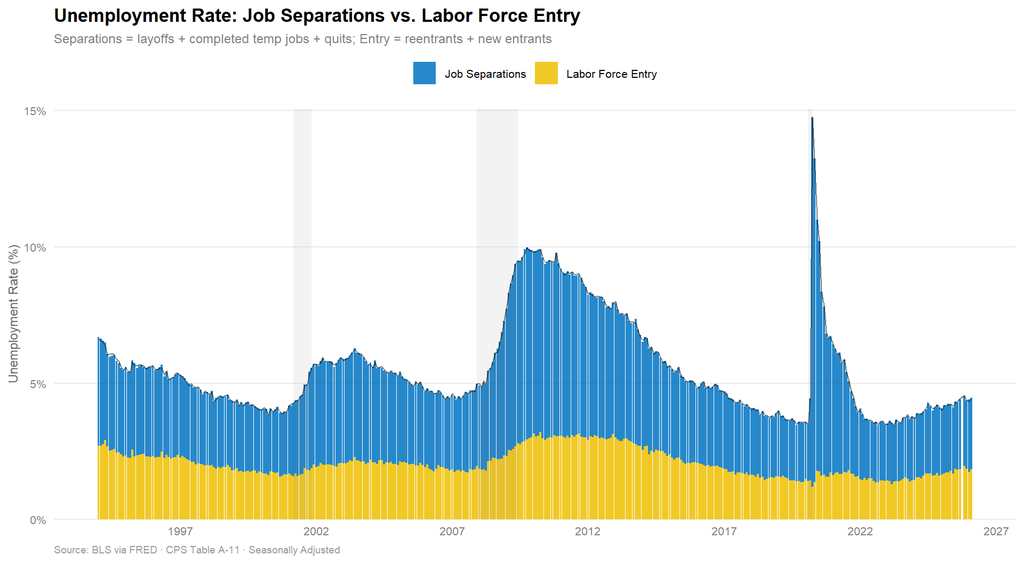

Figure 2: Unemployment rate decomposed into job separations vs. labor force entry. Bars stack to total unemployment rate.

```r
p_cause2 <- df2_long |>
  ggplot(aes(x = date, y = rate, fill = group)) +
  geom_col(alpha = 0.85, width = 28, position = "stack") +
  geom_line(
    data = df2, aes(x = date, y = urate, fill = NULL),
    color = "black", linewidth = 0.4, alpha = 0.5
  ) +
  scale_fill_manual(values = group_cols) +
  scale_y_continuous(labels = \(x) paste0(x, "%"),
                     expand = expansion(mult = c(0, 0.02))) +
  scale_x_date(date_breaks = "5 years", date_labels = "%Y") +
  labs(
    title = "Unemployment Rate: Job Separations vs. Labor Force Entry",
    subtitle = "Separations = layoffs + completed temp jobs + quits; Entry = reentrants + new entrants",
    y = "Unemployment Rate (%)", x = NULL,
    caption = "Source: BLS via FRED · CPS Table A-11 · Seasonally Adjusted"
  )

add_recessions(p_cause2)
```

**Four-Way (Nativity)**

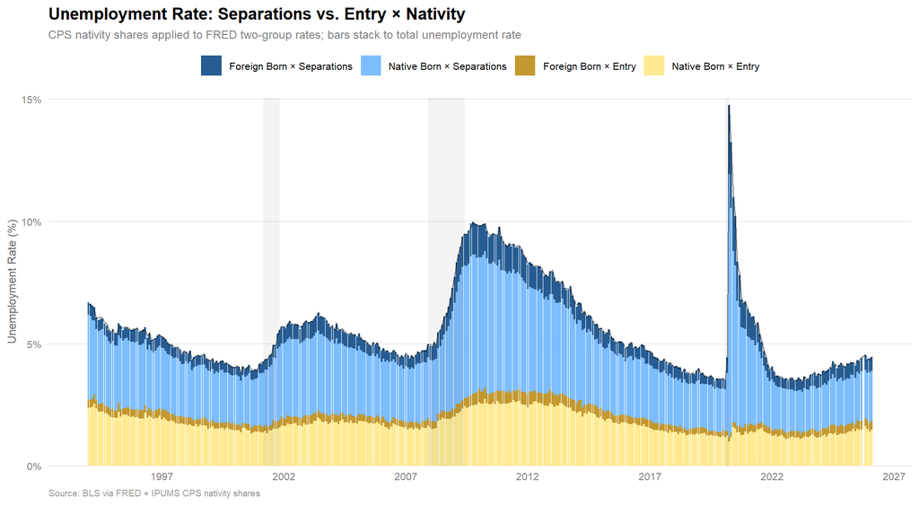

Figure 3: Unemployment rate decomposed by separation/entry × nativity.

```r
p_4nat <- df4_nat_long |>
  ggplot(aes(x = date, y = rate, fill = group)) +
  geom_col(alpha = 0.85, width = 28, position = "stack") +
  geom_line(data = df4_nat, aes(x = date, y = urate, fill = NULL),
            color = "black", linewidth = 0.4, alpha = 0.5) +
  scale_fill_manual(values = fourway_nat_cols) +
  scale_y_continuous(labels = \(x) paste0(x, "%"),
                     expand = expansion(mult = c(0, 0.02))) +
  scale_x_date(date_breaks = "5 years", date_labels = "%Y") +
  labs(title = "Unemployment Rate: Separations vs. Entry × Nativity",
       subtitle = "CPS nativity shares applied to FRED two-group rates; bars stack to total unemployment rate",
       y = "Unemployment Rate (%)", x = NULL,
       caption = "Source: BLS via FRED + IPUMS CPS nativity shares")

add_recessions(p_4nat)
```

**Four-Way (Citizenship)**

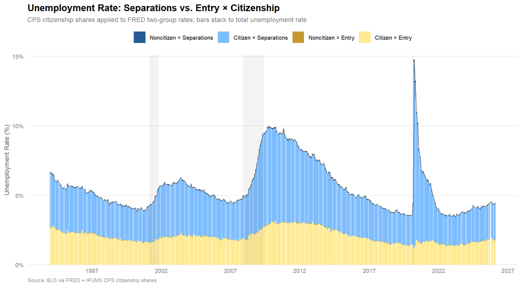

Figure 4: Unemployment rate decomposed by separation/entry × citizenship.

```r
p_4cit <- df4_cit_long |>
  ggplot(aes(x = date, y = rate, fill = group)) +
  geom_col(alpha = 0.85, width = 28, position = "stack") +
  geom_line(data = df4_cit, aes(x = date, y = urate, fill = NULL),
            color = "black", linewidth = 0.4, alpha = 0.5) +
  scale_fill_manual(values = fourway_cit_cols) +
  scale_y_continuous(labels = \(x) paste0(x, "%"),
                     expand = expansion(mult = c(0, 0.02))) +
  scale_x_date(date_breaks = "5 years", date_labels = "%Y") +
  labs(title = "Unemployment Rate: Separations vs. Entry × Citizenship",
       subtitle = "CPS citizenship shares applied to FRED two-group rates; bars stack to total unemployment rate",
       y = "Unemployment Rate (%)", x = NULL,
       caption = "Source: BLS via FRED + IPUMS CPS citizenship shares")

add_recessions(p_4cit)
```

## 1b. Unemployment Rate by Cause — Recent Detail (2023–Present)

**Six-Way**

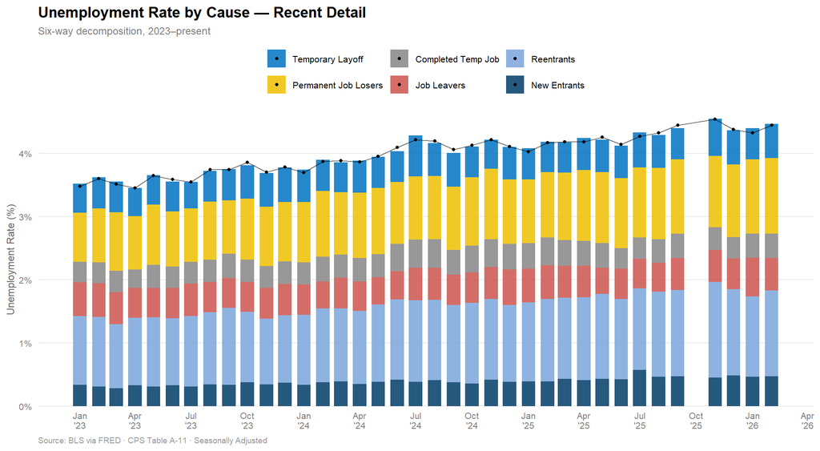

Figure 5: Unemployment rate by cause, zoomed to 2023–present (six-way).

```r
df6_long |>
  filter(date >= as.Date("2023-01-01")) |>
  ggplot(aes(x = date, y = rate, fill = cause)) +
  geom_col(alpha = 0.85, width = 22, position = "stack") +
  geom_line(
    data = df6 |> filter(date >= as.Date("2023-01-01")),
    aes(x = date, y = urate, fill = NULL),
    color = "black", linewidth = 0.5, alpha = 0.5
  ) +
  geom_point(
    data = df6 |> filter(date >= as.Date("2023-01-01")),
    aes(x = date, y = urate, fill = NULL),
    color = "black", size = 1
  ) +
  scale_fill_manual(values = cause_cols) +
  scale_y_continuous(labels = \(x) paste0(x, "%"),
                     expand = expansion(mult = c(0, 0.02))) +
  scale_x_date(date_breaks = "3 months", date_labels = "%b\n'%y") +
  labs(
    title = "Unemployment Rate by Cause — Recent Detail",
    subtitle = "Six-way decomposition, 2023–present",
    y = "Unemployment Rate (%)", x = NULL,
    caption = "Source: BLS via FRED · CPS Table A-11 · Seasonally Adjusted"
  )
```

**Two-Group**

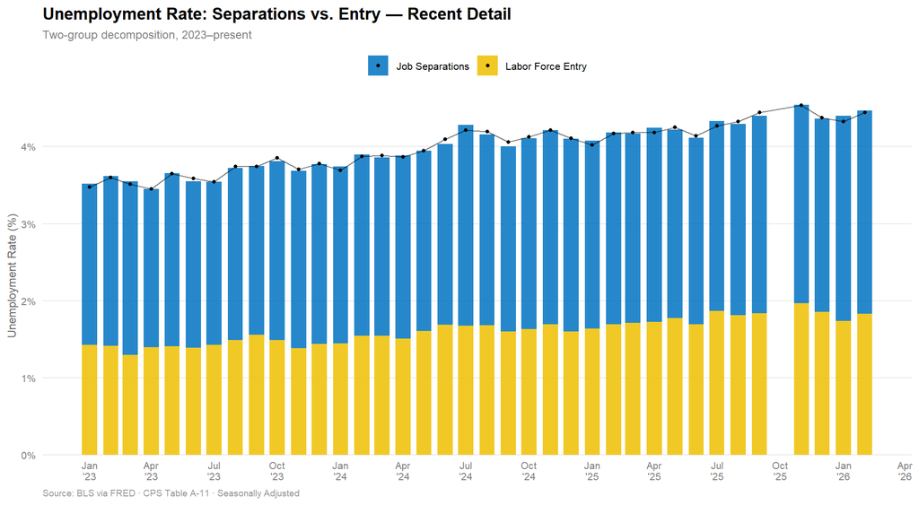

Figure 6: Unemployment rate: separations vs. entry, zoomed to 2023–present.

```r
df2_long |>
  filter(date >= as.Date("2023-01-01")) |>
  ggplot(aes(x = date, y = rate, fill = group)) +
  geom_col(alpha = 0.85, width = 22, position = "stack") +
  geom_line(
    data = df2 |> filter(date >= as.Date("2023-01-01")),
    aes(x = date, y = urate, fill = NULL),
    color = "black", linewidth = 0.5, alpha = 0.5
  ) +
  geom_point(
    data = df2 |> filter(date >= as.Date("2023-01-01")),
    aes(x = date, y = urate, fill = NULL),
    color = "black", size = 1
  ) +
  scale_fill_manual(values = group_cols) +
  scale_y_continuous(labels = \(x) paste0(x, "%"),
                     expand = expansion(mult = c(0, 0.02))) +
  scale_x_date(date_breaks = "3 months", date_labels = "%b\n'%y") +
  labs(
    title = "Unemployment Rate: Separations vs. Entry — Recent Detail",
    subtitle = "Two-group decomposition, 2023–present",
    y = "Unemployment Rate (%)", x = NULL,
    caption = "Source: BLS via FRED · CPS Table A-11 · Seasonally Adjusted"
  )
```

**Four-Way (Nativity)**

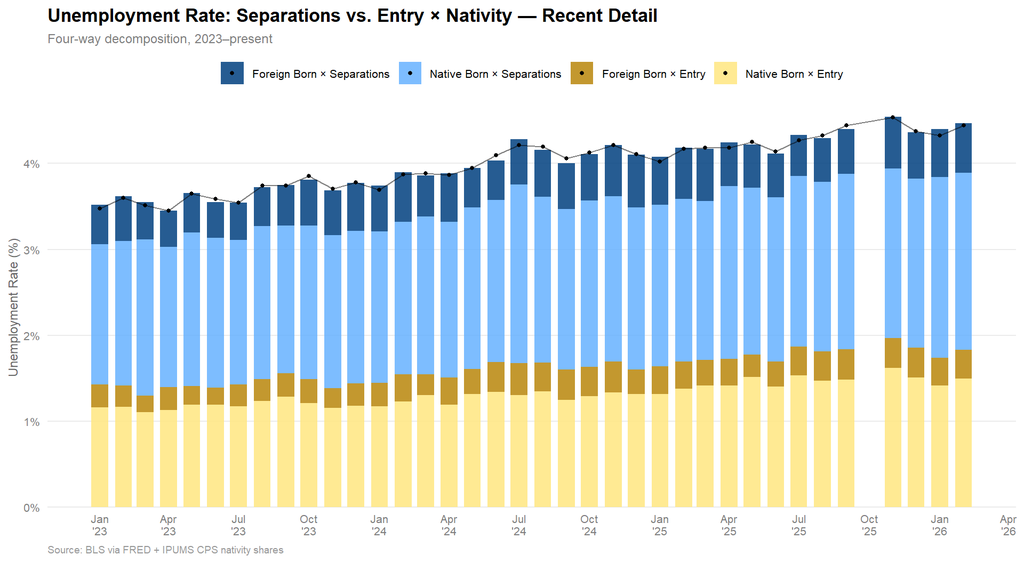

Figure 7: Unemployment rate by separation/entry × nativity, 2023–present.

```r
df4_nat_long |>
  filter(date >= as.Date("2023-01-01")) |>
  ggplot(aes(x = date, y = rate, fill = group)) +
  geom_col(alpha = 0.85, width = 22, position = "stack") +
  geom_line(data = df4_nat |> filter(date >= as.Date("2023-01-01")),
            aes(x = date, y = urate, fill = NULL),
            color = "black", linewidth = 0.5, alpha = 0.5) +
  geom_point(data = df4_nat |> filter(date >= as.Date("2023-01-01")),
             aes(x = date, y = urate, fill = NULL),
             color = "black", size = 1) +
  scale_fill_manual(values = fourway_nat_cols) +
  scale_y_continuous(labels = \(x) paste0(x, "%"),
                     expand = expansion(mult = c(0, 0.02))) +
  scale_x_date(date_breaks = "3 months", date_labels = "%b\n'%y") +
  labs(title = "Unemployment Rate: Separations vs. Entry × Nativity — Recent Detail",
       subtitle = "Four-way decomposition, 2023–present",
       y = "Unemployment Rate (%)", x = NULL,
       caption = "Source: BLS via FRED + IPUMS CPS nativity shares")
```

**Four-Way (Citizenship)**

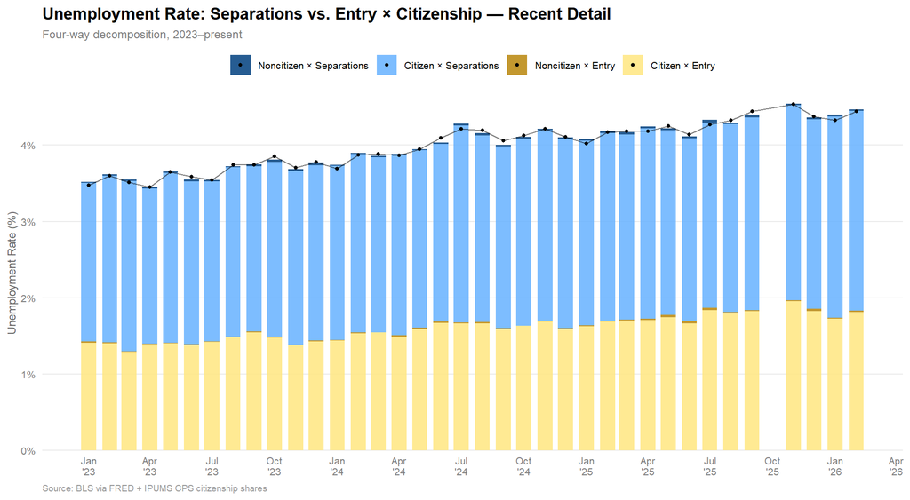

Figure 8: Unemployment rate by separation/entry × citizenship, 2023–present.

```r
df4_cit_long |>
  filter(date >= as.Date("2023-01-01")) |>
  ggplot(aes(x = date, y = rate, fill = group)) +
  geom_col(alpha = 0.85, width = 22, position = "stack") +
  geom_line(data = df4_cit |> filter(date >= as.Date("2023-01-01")),
            aes(x = date, y = urate, fill = NULL),
            color = "black", linewidth = 0.5, alpha = 0.5) +
  geom_point(data = df4_cit |> filter(date >= as.Date("2023-01-01")),
             aes(x = date, y = urate, fill = NULL),
             color = "black", size = 1) +
  scale_fill_manual(values = fourway_cit_cols) +
  scale_y_continuous(labels = \(x) paste0(x, "%"),
                     expand = expansion(mult = c(0, 0.02))) +
  scale_x_date(date_breaks = "3 months", date_labels = "%b\n'%y") +
  labs(title = "Unemployment Rate: Separations vs. Entry × Citizenship — Recent Detail",
       subtitle = "Four-way decomposition, 2023–present",
       y = "Unemployment Rate (%)", x = NULL,
       caption = "Source: BLS via FRED + IPUMS CPS citizenship shares")
```

## 2. Change in Unemployment Rate by Cause

```r
# Compute YoY change in each cause's rate contribution (six-way)
df6_chg <- df6 |>
  arrange(date) |>
  mutate(
    across(all_of(paste0(cause_order, "_rate")),
           \(x) x - lag(x, 12),
           .names = "{.col}_chg"),
    urate_chg = urate - lag(urate, 12)
  ) |>
  filter(!is.na(urate_chg))

df6_chg_long <- df6_chg |>
  select(date, ends_with("_rate_chg")) |>
  pivot_longer(-date, names_to = "cause", values_to = "chg") |>
  mutate(
    cause = str_remove(cause, "_rate_chg"),
    cause = factor(cause, levels = cause_order)
  )

# Compute YoY change (two-group)
df2_chg <- df2 |>
  arrange(date) |>
  mutate(
    `Job Separations_rate_chg` = `Job Separations_rate` - lag(`Job Separations_rate`, 12),
    `Labor Force Entry_rate_chg` = `Labor Force Entry_rate` - lag(`Labor Force Entry_rate`, 12),
    urate_chg = urate - lag(urate, 12)
  ) |>
  filter(!is.na(urate_chg))

df2_chg_long <- df2_chg |>
  select(date, ends_with("_rate_chg")) |>
  pivot_longer(-date, names_to = "group", values_to = "chg") |>
  mutate(
    group = str_remove(group, "_rate_chg"),
    group = factor(group, levels = group_order)
  )
```

**Six-Way**

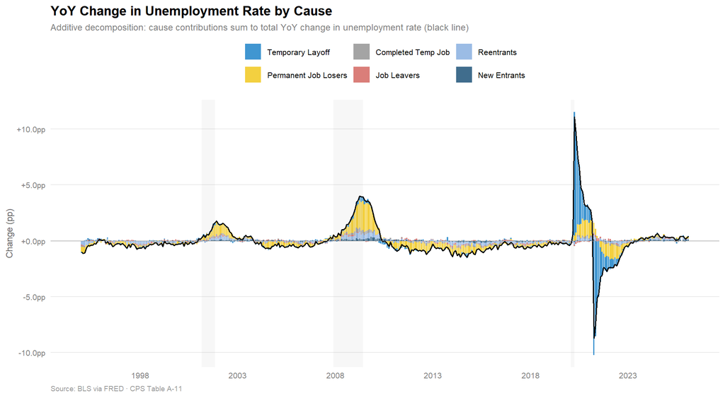

Figure 9: Year-over-year change in unemployment rate decomposed by cause (six-way).

```r
p_cause_chg <- df6_chg_long |>
  ggplot(aes(x = date, y = chg, fill = cause)) +
  geom_col(alpha = 0.75, width = 25) +
  geom_line(
    data = df6_chg, aes(x = date, y = urate_chg, fill = NULL),
    color = "black", linewidth = 0.6
  ) +
  geom_hline(yintercept = 0, color = "grey60", linewidth = 0.3) +
  scale_fill_manual(values = cause_cols) +
  scale_y_continuous(labels = \(x) paste0(sprintf("%+.1f", x), "pp")) +
  scale_x_date(date_breaks = "5 years", date_labels = "%Y") +
  labs(
    title = "YoY Change in Unemployment Rate by Cause",
    subtitle = "Additive decomposition: cause contributions sum to total YoY change in unemployment rate (black line)",
    y = "Change (pp)", x = NULL,
    caption = "Source: BLS via FRED · CPS Table A-11"
  )

add_recessions(p_cause_chg, alpha = 0.05)
```

**Two-Group**

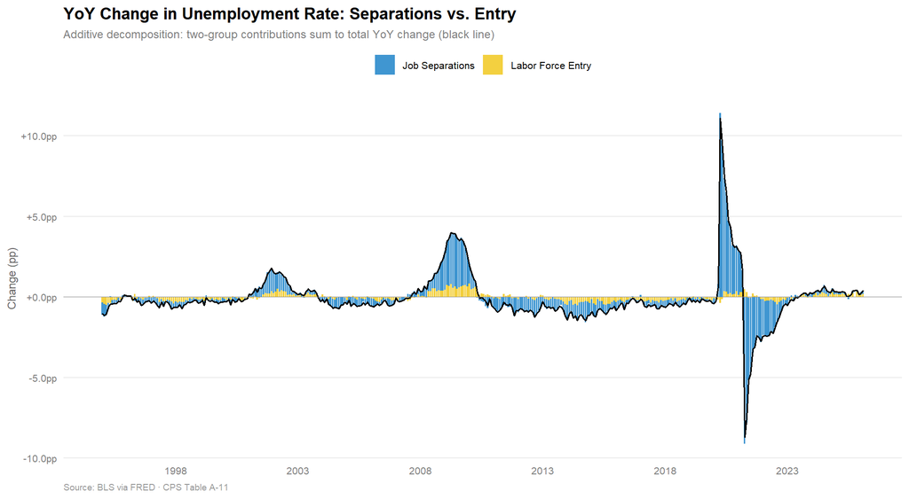

Figure 10: Year-over-year change in unemployment rate: job separations vs. labor force entry.

```r
df2_chg_long |>
  ggplot(aes(x = date, y = chg, fill = group)) +
  geom_col(alpha = 0.75, width = 25) +
  geom_line(
    data = df2_chg, aes(x = date, y = urate_chg, fill = NULL),
    color = "black", linewidth = 0.6
  ) +
  geom_hline(yintercept = 0, color = "grey60", linewidth = 0.3) +
  scale_fill_manual(values = group_cols) +
  scale_y_continuous(labels = \(x) paste0(sprintf("%+.1f", x), "pp")) +
  scale_x_date(date_breaks = "5 years", date_labels = "%Y") +
  labs(
    title = "YoY Change in Unemployment Rate: Separations vs. Entry",
    subtitle = "Additive decomposition: two-group contributions sum to total YoY change (black line)",
    y = "Change (pp)", x = NULL,
    caption = "Source: BLS via FRED · CPS Table A-11"
  )
```

**Four-Way (Nativity)**

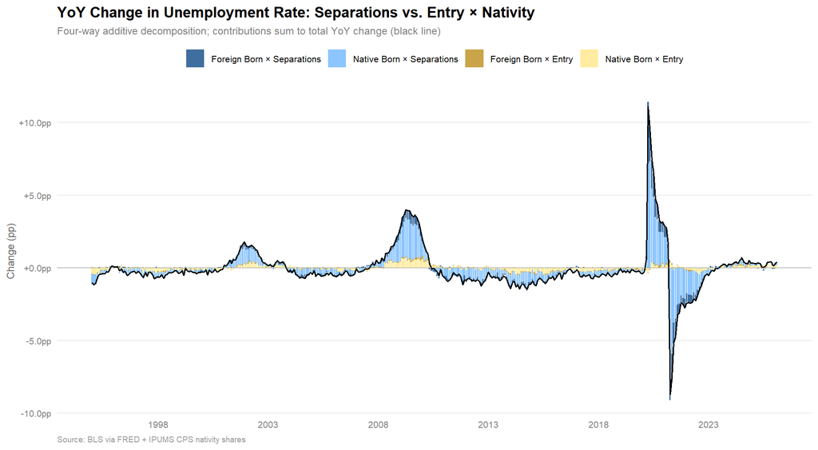

Figure 11: YoY change in unemployment rate by separation/entry × nativity.

```r
df4_nat_chg_long |>
  ggplot(aes(x = date, y = chg, fill = group)) +
  geom_col(alpha = 0.75, width = 25) +
  geom_line(data = df4_nat_chg, aes(x = date, y = urate_chg, fill = NULL),
            color = "black", linewidth = 0.6) +
  geom_hline(yintercept = 0, color = "grey60", linewidth = 0.3) +
  scale_fill_manual(values = fourway_nat_cols) +
  scale_y_continuous(labels = \(x) paste0(sprintf("%+.1f", x), "pp")) +
  scale_x_date(date_breaks = "5 years", date_labels = "%Y") +
  labs(title = "YoY Change in Unemployment Rate: Separations vs. Entry × Nativity",
       subtitle = "Four-way additive decomposition; contributions sum to total YoY change (black line)",
       y = "Change (pp)", x = NULL,
       caption = "Source: BLS via FRED + IPUMS CPS nativity shares")
```

**Four-Way (Citizenship)**

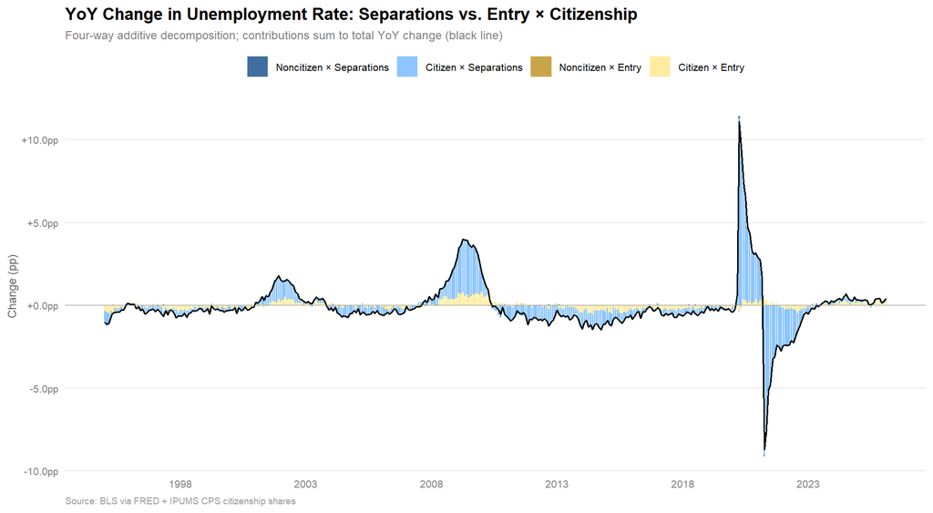

Figure 12: YoY change in unemployment rate by separation/entry × citizenship.

```r
df4_cit_chg_long |>
  ggplot(aes(x = date, y = chg, fill = group)) +
  geom_col(alpha = 0.75, width = 25) +
  geom_line(data = df4_cit_chg, aes(x = date, y = urate_chg, fill = NULL),
            color = "black", linewidth = 0.6) +
  geom_hline(yintercept = 0, color = "grey60", linewidth = 0.3) +
  scale_fill_manual(values = fourway_cit_cols) +
  scale_y_continuous(labels = \(x) paste0(sprintf("%+.1f", x), "pp")) +
  scale_x_date(date_breaks = "5 years", date_labels = "%Y") +
  labs(title = "YoY Change in Unemployment Rate: Separations vs. Entry × Citizenship",
       subtitle = "Four-way additive decomposition; contributions sum to total YoY change (black line)",
       y = "Change (pp)", x = NULL,
       caption = "Source: BLS via FRED + IPUMS CPS citizenship shares")
```

The change decomposition reveals which causes are driving movements in the unemployment rate. Job separations drive virtually all recessionary surges and recoveries. Labor force entry contributes a smaller, more stable component to rate changes.

## 3. Recent Detail: Change in Unemployment Rate by Cause (2023–Present)

```r
df6_chg_recent <- df6_chg |> filter(date >= as.Date("2023-01-01"))
df6_chg_recent_long <- df6_chg_long |> filter(date >= as.Date("2023-01-01"))
df2_chg_recent <- df2_chg |> filter(date >= as.Date("2023-01-01"))
df2_chg_recent_long <- df2_chg_long |> filter(date >= as.Date("2023-01-01"))
```

**Six-Way**

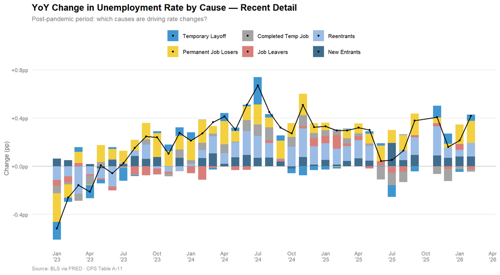

Figure 13: Year-over-year change in unemployment rate by cause, zoomed to the post-pandemic period (six-way).

```r
df6_chg_recent_long |>
  ggplot(aes(x = date, y = chg, fill = cause)) +
  geom_col(alpha = 0.75, width = 22) +
  geom_line(
    data = df6_chg_recent, aes(x = date, y = urate_chg, fill = NULL),
    color = "black", linewidth = 0.7
  ) +
  geom_point(
    data = df6_chg_recent, aes(x = date, y = urate_chg, fill = NULL),
    color = "black", size = 1
  ) +
  geom_hline(yintercept = 0, color = "grey60", linewidth = 0.3) +
  scale_fill_manual(values = cause_cols) +
  scale_y_continuous(labels = \(x) paste0(sprintf("%+.1f", x), "pp")) +
  scale_x_date(date_breaks = "3 months", date_labels = "%b\n'%y") +
  labs(
    title = "YoY Change in Unemployment Rate by Cause — Recent Detail",
    subtitle = "Post-pandemic period: which causes are driving rate changes?",
    y = "Change (pp)", x = NULL,
    caption = "Source: BLS via FRED · CPS Table A-11"
  )
```

**Two-Group**

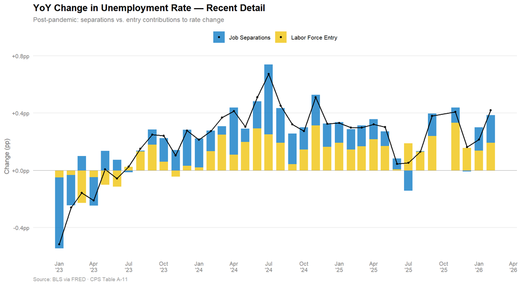

Figure 14: Year-over-year change in unemployment rate: job separations vs. labor force entry, post-pandemic.

```r
df2_chg_recent_long |>
  ggplot(aes(x = date, y = chg, fill = group)) +
  geom_col(alpha = 0.75, width = 22) +
  geom_line(
    data = df2_chg_recent, aes(x = date, y = urate_chg, fill = NULL),
    color = "black", linewidth = 0.7
  ) +
  geom_point(
    data = df2_chg_recent, aes(x = date, y = urate_chg, fill = NULL),
    color = "black", size = 1
  ) +
  geom_hline(yintercept = 0, color = "grey60", linewidth = 0.3) +
  scale_fill_manual(values = group_cols) +
  scale_y_continuous(labels = \(x) paste0(sprintf("%+.1f", x), "pp")) +
  scale_x_date(date_breaks = "3 months", date_labels = "%b\n'%y") +
  labs(
    title = "YoY Change in Unemployment Rate — Recent Detail",
    subtitle = "Post-pandemic: separations vs. entry contributions to rate change",
    y = "Change (pp)", x = NULL,
    caption = "Source: BLS via FRED · CPS Table A-11"
  )
```

**Four-Way (Nativity)**

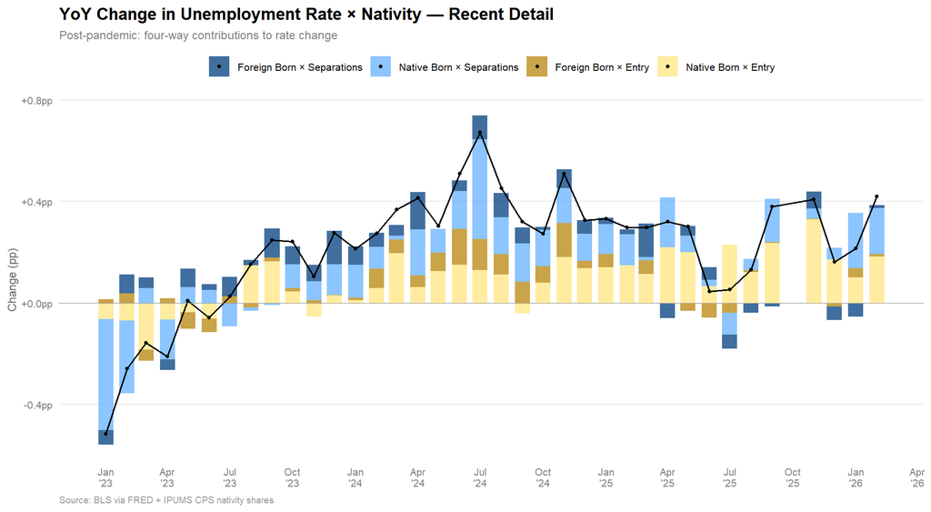

Figure 15: YoY change in unemployment rate by separation/entry × nativity, 2023–present.

```r
df4_nat_chg_recent_long |>
  ggplot(aes(x = date, y = chg, fill = group)) +
  geom_col(alpha = 0.75, width = 22) +
  geom_line(data = df4_nat_chg_recent, aes(x = date, y = urate_chg, fill = NULL),
            color = "black", linewidth = 0.7) +
  geom_point(data = df4_nat_chg_recent, aes(x = date, y = urate_chg, fill = NULL),
             color = "black", size = 1) +
  geom_hline(yintercept = 0, color = "grey60", linewidth = 0.3) +
  scale_fill_manual(values = fourway_nat_cols) +
  scale_y_continuous(labels = \(x) paste0(sprintf("%+.1f", x), "pp")) +
  scale_x_date(date_breaks = "3 months", date_labels = "%b\n'%y") +
  labs(title = "YoY Change in Unemployment Rate × Nativity — Recent Detail",
       subtitle = "Post-pandemic: four-way contributions to rate change",
       y = "Change (pp)", x = NULL,
       caption = "Source: BLS via FRED + IPUMS CPS nativity shares")
```

**Four-Way (Citizenship)**

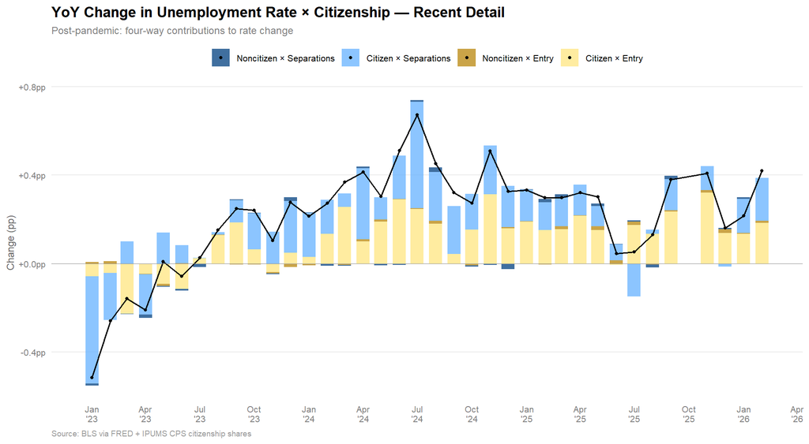

Figure 16: YoY change in unemployment rate by separation/entry × citizenship, 2023–present.

```r
df4_cit_chg_recent_long |>
  ggplot(aes(x = date, y = chg, fill = group)) +
  geom_col(alpha = 0.75, width = 22) +
  geom_line(data = df4_cit_chg_recent, aes(x = date, y = urate_chg, fill = NULL),
            color = "black", linewidth = 0.7) +
  geom_point(data = df4_cit_chg_recent, aes(x = date, y = urate_chg, fill = NULL),
             color = "black", size = 1) +
  geom_hline(yintercept = 0, color = "grey60", linewidth = 0.3) +
  scale_fill_manual(values = fourway_cit_cols) +
  scale_y_continuous(labels = \(x) paste0(sprintf("%+.1f", x), "pp")) +
  scale_x_date(date_breaks = "3 months", date_labels = "%b\n'%y") +
  labs(title = "YoY Change in Unemployment Rate × Citizenship — Recent Detail",
       subtitle = "Post-pandemic: four-way contributions to rate change",
       y = "Change (pp)", x = NULL,
       caption = "Source: BLS via FRED + IPUMS CPS citizenship shares")
```

## 4. Unemployment Composition: Stacked Shares (1994–Present)

```r
# Compute six-way shares relative to component sum so they stack to exactly 100%
df6_shares <- df6 |>
  mutate(
    component_sum = `Temporary Layoff` + `Permanent Job Losers` + `Completed Temp Job` +
                    `Job Leavers` + Reentrants + `New Entrants`,
    across(all_of(cause_order),
           \(x) x / component_sum * 100,
           .names = "{.col}_share")
  ) |>
  select(date, ends_with("_share")) |>
  pivot_longer(-date, names_to = "cause", values_to = "share") |>
  mutate(
    cause = str_remove(cause, "_share"),
    cause = factor(cause, levels = cause_order)
  )

# Compute two-group shares
df2_shares <- df2 |>
  mutate(
    component_sum = `Job Separations` + `Labor Force Entry`,
    `Job Separations_share` = `Job Separations` / component_sum * 100,
    `Labor Force Entry_share` = `Labor Force Entry` / component_sum * 100
  ) |>
  select(date, `Job Separations_share`, `Labor Force Entry_share`) |>
  pivot_longer(-date, names_to = "group", values_to = "share") |>
  mutate(
    group = str_remove(group, "_share"),
    group = factor(group, levels = group_order)
  )
```

**Six-Way**

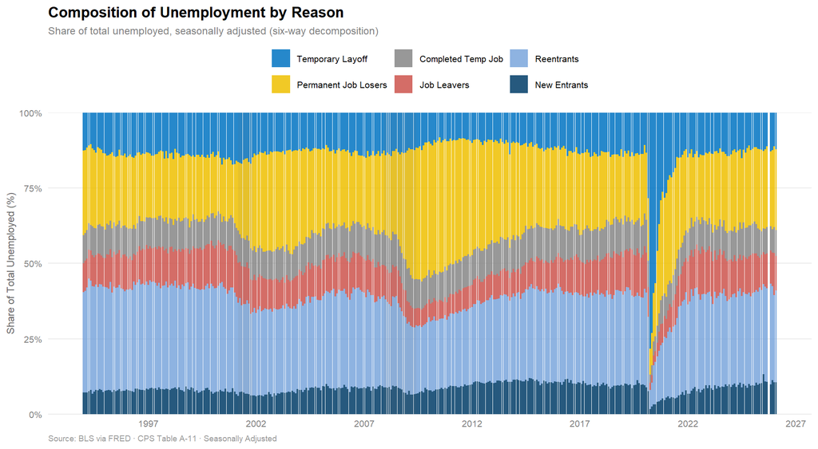

Figure 17: Share of total unemployment by reason (six-way). Shaded areas indicate NBER recessions.

```r
p_stacked <- df6_shares |>
  ggplot(aes(x = date, y = share, fill = cause)) +
  geom_col(alpha = 0.85, width = 28, position = "stack") +
  scale_fill_manual(values = cause_cols) +
  scale_y_continuous(labels = \(x) paste0(x, "%"), limits = c(0, 100),
                     expand = expansion(mult = c(0, 0))) +
  scale_x_date(date_breaks = "5 years", date_labels = "%Y") +
  labs(
    title = "Composition of Unemployment by Reason",
    subtitle = "Share of total unemployed, seasonally adjusted (six-way decomposition)",
    y = "Share of Total Unemployed (%)", x = NULL,
    caption = "Source: BLS via FRED · CPS Table A-11 · Seasonally Adjusted"
  )

add_recessions(p_stacked)
```

**Two-Group**

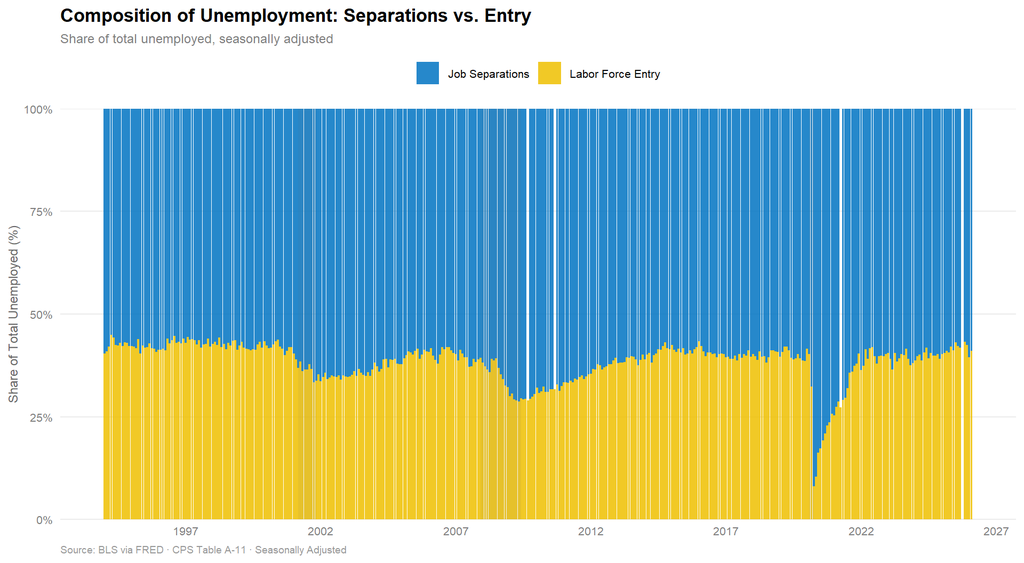

Figure 18: Share of total unemployment: job separations vs. labor force entry.

```r
p_stacked2 <- df2_shares |>
  ggplot(aes(x = date, y = share, fill = group)) +
  geom_col(alpha = 0.85, width = 28, position = "stack") +
  scale_fill_manual(values = group_cols) +
  scale_y_continuous(labels = \(x) paste0(x, "%"), limits = c(0, 100),
                     expand = expansion(mult = c(0, 0))) +
  scale_x_date(date_breaks = "5 years", date_labels = "%Y") +
  labs(
    title = "Composition of Unemployment: Separations vs. Entry",
    subtitle = "Share of total unemployed, seasonally adjusted",
    y = "Share of Total Unemployed (%)", x = NULL,
    caption = "Source: BLS via FRED · CPS Table A-11 · Seasonally Adjusted"
  )

add_recessions(p_stacked2)
```

## 5. New Entrants Share

**Share of Total Unemployed**

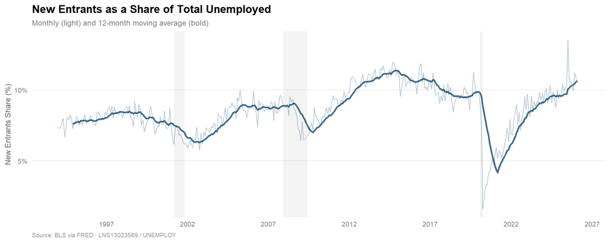

Figure 19: New entrant share of total unemployment with 12-month moving average.

```r
ne_share <- df6 |>
  transmute(date, share = `New Entrants` / Total * 100) |>
  mutate(ma12 = zoo::rollmean(share, k = 12, fill = NA, align = "right"))

p_ne <- ne_share |>
  ggplot(aes(x = date)) +
  geom_line(aes(y = share), color = cause_cols["New Entrants"], alpha = 0.3, linewidth = 0.4) +
  geom_line(aes(y = ma12), color = cause_cols["New Entrants"], linewidth = 1, alpha = 0.75) +
  scale_y_continuous(labels = \(x) paste0(x, "%")) +
  scale_x_date(date_breaks = "5 years", date_labels = "%Y") +
  labs(
    title = "New Entrants as a Share of Total Unemployed",
    subtitle = "Monthly (light) and 12-month moving average (bold)",
    y = "New Entrants Share (%)", x = NULL,
    caption = "Source: BLS via FRED · LNS13023569 / UNEMPLOY"
  )

add_recessions(p_ne)
```

**Share of Labor Force**

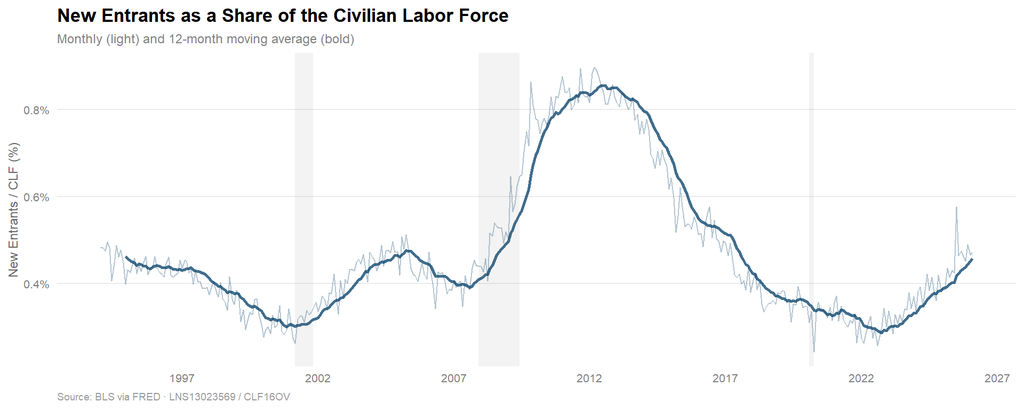

Figure 20: New entrants as a share of the civilian labor force with 12-month moving average.

```r
ne_clf <- df6 |>
  transmute(date, share = `New Entrants` / CLF * 100) |>
  mutate(ma12 = zoo::rollmean(share, k = 12, fill = NA, align = "right"))

p_ne_clf <- ne_clf |>
  ggplot(aes(x = date)) +
  geom_line(aes(y = share), color = cause_cols["New Entrants"], alpha = 0.3, linewidth = 0.4) +
  geom_line(aes(y = ma12), color = cause_cols["New Entrants"], linewidth = 1, alpha = 0.75) +
  scale_y_continuous(labels = \(x) paste0(x, "%")) +
  scale_x_date(date_breaks = "5 years", date_labels = "%Y") +
  labs(
    title = "New Entrants as a Share of the Civilian Labor Force",
    subtitle = "Monthly (light) and 12-month moving average (bold)",
    y = "New Entrants / CLF (%)", x = NULL,
    caption = "Source: BLS via FRED · LNS13023569 / CLF16OV"
  )

add_recessions(p_ne_clf)
```

## 5b. Nativity × Cause Group Shares

These charts decompose the unemployed and labor force along two dimensions — cause group (job separations vs. labor force entry) and nativity (foreign-born vs. native-born) — to reveal whether shifts in the composition of unemployment are driven by changes in *who* is becoming unemployed or *why*.

```r
nativity_share_data = read_final_parquet("unemployment_nativity_shares.parquet")

shares_unemp = nativity_share_data |>
  filter(panel == "share_of_total_unemployed")

fb_within = nativity_share_data |>
  filter(panel == "foreign_born_share_within_group")

share_cols = c(
  "LF Entrants"         = "#EFC000",
  "Job Separators"      = "#0073C2",
  "Foreign Born"        = "#CD534C",
  "Native Born"         = "#868686",
  "LF Entrants × FB"   = "#E69F00",
  "Job Separators × FB" = "#56B4E9"
)

facet_labels = c(
  "LF Entrants"        = "LF Entrants",
  "Job Separators"     = "Job Separators",
  "Foreign Born"       = "Foreign Born",
  "Native Born"        = "Native Born",
  "LF Entrants × FB"  = "LF Entrants × Foreign Born",
  "Job Separators × FB" = "Job Separators × Foreign Born"
)

fb_within_cols = c(
  "All Unemployed" = "#CD534C",
  "LF Entrants"   = "#EFC000",
  "Job Separators" = "#0073C2",
  "Labor Force"   = "#868686"
)
```

**Share of Total Unemployed**

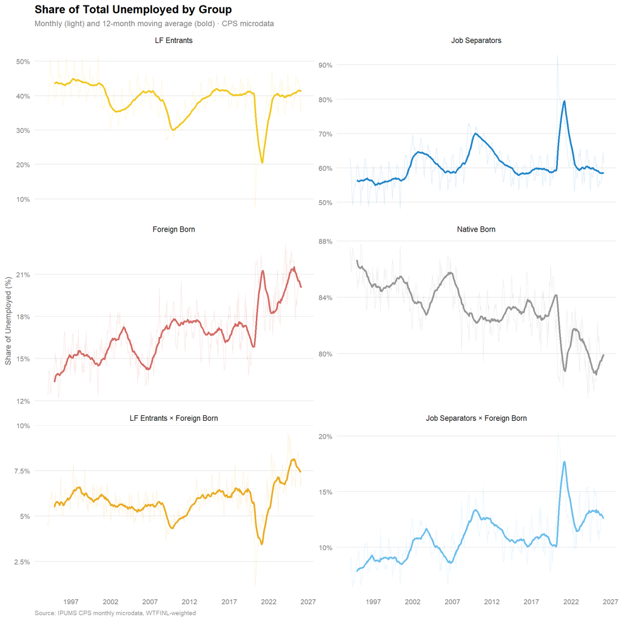

Figure 21: Each group’s share of total unemployed, monthly (light) with 12-month moving average (bold).

```r
shares_unemp |>
  ggplot(aes(x = date)) +
  geom_line(aes(y = share, color = series), alpha = 0.2, linewidth = 0.3) +
  geom_line(aes(y = ma12, color = series), linewidth = 0.9, alpha = 0.85) +
  facet_wrap(~ series, ncol = 2, scales = "free_y",
             labeller = labeller(series = facet_labels)) +
  scale_color_manual(values = share_cols, guide = "none") +
  scale_y_continuous(labels = \(x) paste0(x, "%")) +
  scale_x_date(date_breaks = "5 years", date_labels = "%Y") +
  labs(title = "Share of Total Unemployed by Group",
       subtitle = "Monthly (light) and 12-month moving average (bold) · CPS microdata",
       y = "Share of Unemployed (%)", x = NULL,
       caption = "Source: IPUMS CPS monthly microdata, WTFINL-weighted")
```

**Foreign-Born Share Within Group**

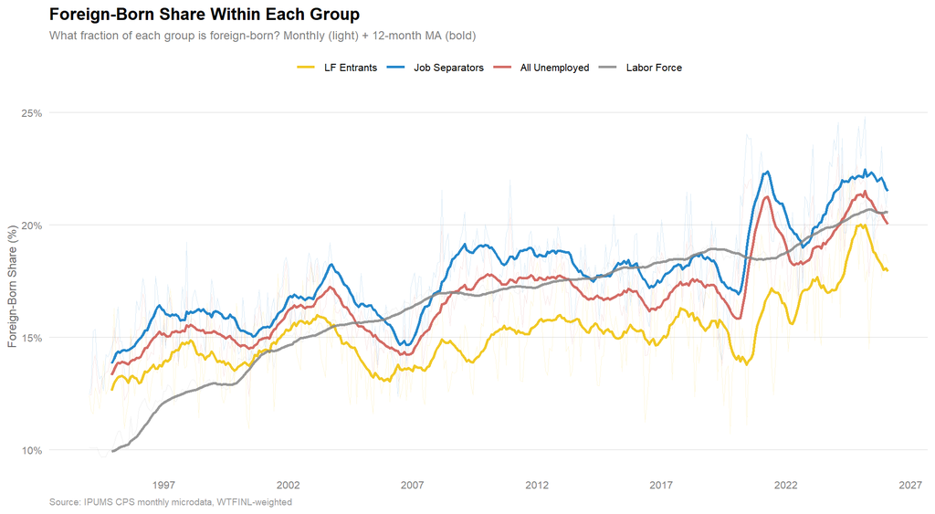

Figure 22: Foreign-born share within each group: what % of LF entrants, job separators, all unemployed, and the labor force is foreign-born?

```r
fb_within |>
  ggplot(aes(x = date)) +
  geom_line(aes(y = share, color = series), alpha = 0.15, linewidth = 0.3) +
  geom_line(aes(y = ma12, color = series), linewidth = 1, alpha = 0.85) +
  scale_color_manual(values = fb_within_cols) +
  scale_y_continuous(labels = \(x) paste0(x, "%")) +
  scale_x_date(date_breaks = "5 years", date_labels = "%Y") +
  labs(title = "Foreign-Born Share Within Each Group",
       subtitle = "What fraction of each group is foreign-born? Monthly (light) + 12-month MA (bold)",
       y = "Foreign-Born Share (%)", x = NULL,
       caption = "Source: IPUMS CPS monthly microdata, WTFINL-weighted") +
  theme(legend.position = "top")
```

## 6. YoY Contributions to Unemployment Growth (1995–Present)

```r
# ── Contribution decomposition functions ─────────────────────────────────
calc_contributions6 <- function(data, lag = 12, start_date = NULL) {
  data |>
    arrange(date) |>
    mutate(
      across(all_of(cause_order),
             \(x) (x - lag(x, lag)) / lag(Total, lag) * 100,
             .names = "{.col}_contrib"),
      total_chg = (Total - lag(Total, lag)) / lag(Total, lag) * 100
    ) |>
    filter(!is.na(total_chg)) |>
    (\(d) if (!is.null(start_date)) filter(d, date >= start_date) else d)()
}

calc_contributions2 <- function(data, lag = 12, start_date = NULL) {
  data |>
    arrange(date) |>
    mutate(
      across(all_of(group_order),
             \(x) (x - lag(x, lag)) / lag(Total, lag) * 100,
             .names = "{.col}_contrib"),
      total_chg = (Total - lag(Total, lag)) / lag(Total, lag) * 100
    ) |>
    filter(!is.na(total_chg)) |>
    (\(d) if (!is.null(start_date)) filter(d, date >= start_date) else d)()
}

# Six-way YoY
df_yoy <- calc_contributions6(df6, lag = 12)

df_yoy_long <- df_yoy |>
  select(date, ends_with("_contrib"), total_chg) |>
  pivot_longer(
    cols = ends_with("_contrib"),
    names_to = "cause",
    values_to = "contrib"
  ) |>
  mutate(
    cause = str_remove(cause, "_contrib"),
    cause = factor(cause, levels = cause_order)
  )

# Two-group YoY
df_yoy2 <- calc_contributions2(df2, lag = 12)

df_yoy2_long <- df_yoy2 |>
  select(date, ends_with("_contrib"), total_chg) |>
  pivot_longer(
    cols = ends_with("_contrib"),
    names_to = "group",
    values_to = "contrib"
  ) |>
  mutate(
    group = str_remove(group, "_contrib"),
    group = factor(group, levels = group_order)
  )
```

**Six-Way**

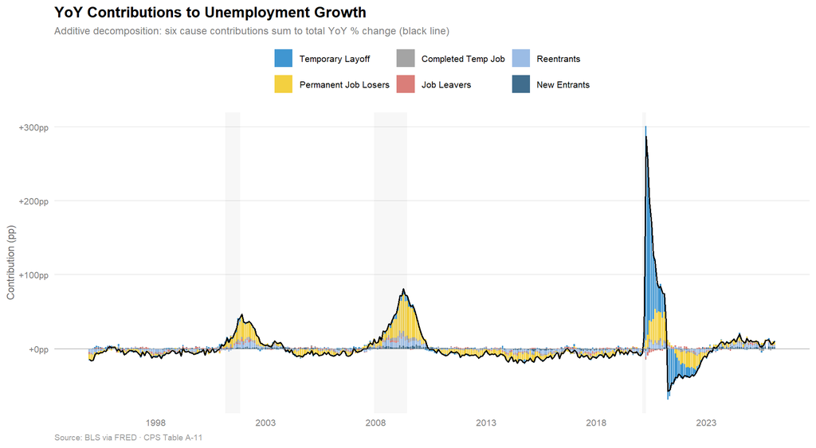

Figure 23: Year-over-year contributions to total unemployment change by reason (six-way).

```r
p_yoy <- df_yoy_long |>
  ggplot(aes(x = date, y = contrib, fill = cause)) +
  geom_col(alpha = 0.75, width = 25) +
  geom_line(
    data = df_yoy, aes(x = date, y = total_chg, fill = NULL),
    color = "black", linewidth = 0.6
  ) +
  geom_hline(yintercept = 0, color = "grey60", linewidth = 0.3) +
  scale_fill_manual(values = cause_cols) +
  scale_y_continuous(labels = \(x) paste0(sprintf("%+.0f", x), "pp")) +
  scale_x_date(date_breaks = "5 years", date_labels = "%Y") +
  labs(
    title = "YoY Contributions to Unemployment Growth",
    subtitle = "Additive decomposition: six cause contributions sum to total YoY % change (black line)",
    y = "Contribution (pp)", x = NULL,
    caption = "Source: BLS via FRED · CPS Table A-11"
  )

add_recessions(p_yoy, alpha = 0.05)
```

**Two-Group**

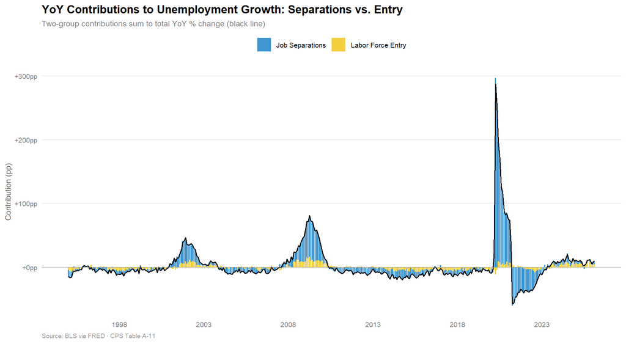

Figure 24: Year-over-year contributions to unemployment change: separations vs. entry.

```r
df_yoy2_long |>
  ggplot(aes(x = date, y = contrib, fill = group)) +
  geom_col(alpha = 0.75, width = 25) +
  geom_line(
    data = df_yoy2, aes(x = date, y = total_chg, fill = NULL),
    color = "black", linewidth = 0.6
  ) +
  geom_hline(yintercept = 0, color = "grey60", linewidth = 0.3) +
  scale_fill_manual(values = group_cols) +
  scale_y_continuous(labels = \(x) paste0(sprintf("%+.0f", x), "pp")) +
  scale_x_date(date_breaks = "5 years", date_labels = "%Y") +
  labs(
    title = "YoY Contributions to Unemployment Growth: Separations vs. Entry",
    subtitle = "Two-group contributions sum to total YoY % change (black line)",
    y = "Contribution (pp)", x = NULL,
    caption = "Source: BLS via FRED · CPS Table A-11"
  )
```

Each bar decomposes the YoY % change in total unemployment into additive contributions. Job separations drive virtually all cyclical swings. Labor force entry contributes modestly and more steadily.

## 7. YoY Contributions — Recent Detail (2023–Present)

```r
df_yoy_recent <- calc_contributions6(df6, lag = 12, start_date = as.Date("2023-01-01"))
df_yoy_recent_long <- df_yoy_recent |>
  select(date, ends_with("_contrib"), total_chg) |>
  pivot_longer(ends_with("_contrib"), names_to = "cause", values_to = "contrib") |>
  mutate(cause = str_remove(cause, "_contrib"), cause = factor(cause, levels = cause_order))

df_yoy_recent2 <- calc_contributions2(df2, lag = 12, start_date = as.Date("2023-01-01"))
df_yoy_recent2_long <- df_yoy_recent2 |>
  select(date, ends_with("_contrib"), total_chg) |>
  pivot_longer(ends_with("_contrib"), names_to = "group", values_to = "contrib") |>
  mutate(group = str_remove(group, "_contrib"), group = factor(group, levels = group_order))
```

**Six-Way**

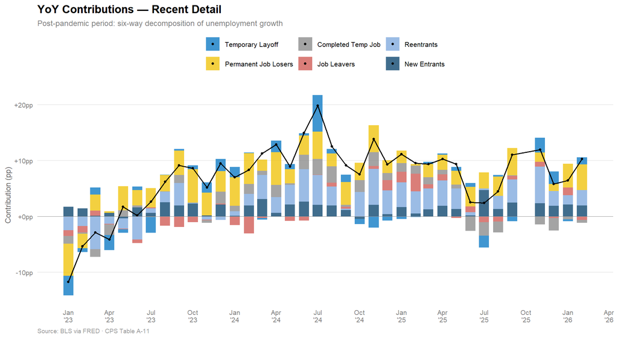

Figure 25: Year-over-year contributions zoomed to the post-pandemic period (six-way).

```r
df_yoy_recent_long |>
  ggplot(aes(x = date, y = contrib, fill = cause)) +
  geom_col(alpha = 0.75, width = 22) +
  geom_line(
    data = df_yoy_recent, aes(x = date, y = total_chg, fill = NULL),
    color = "black", linewidth = 0.7
  ) +
  geom_point(
    data = df_yoy_recent, aes(x = date, y = total_chg, fill = NULL),
    color = "black", size = 1
  ) +
  geom_hline(yintercept = 0, color = "grey60", linewidth = 0.3) +
  scale_fill_manual(values = cause_cols) +
  scale_y_continuous(labels = \(x) paste0(sprintf("%+.0f", x), "pp")) +
  scale_x_date(date_breaks = "3 months", date_labels = "%b\n'%y") +
  labs(
    title = "YoY Contributions — Recent Detail",
    subtitle = "Post-pandemic period: six-way decomposition of unemployment growth",
    y = "Contribution (pp)", x = NULL,
    caption = "Source: BLS via FRED · CPS Table A-11"
  )
```

**Two-Group**

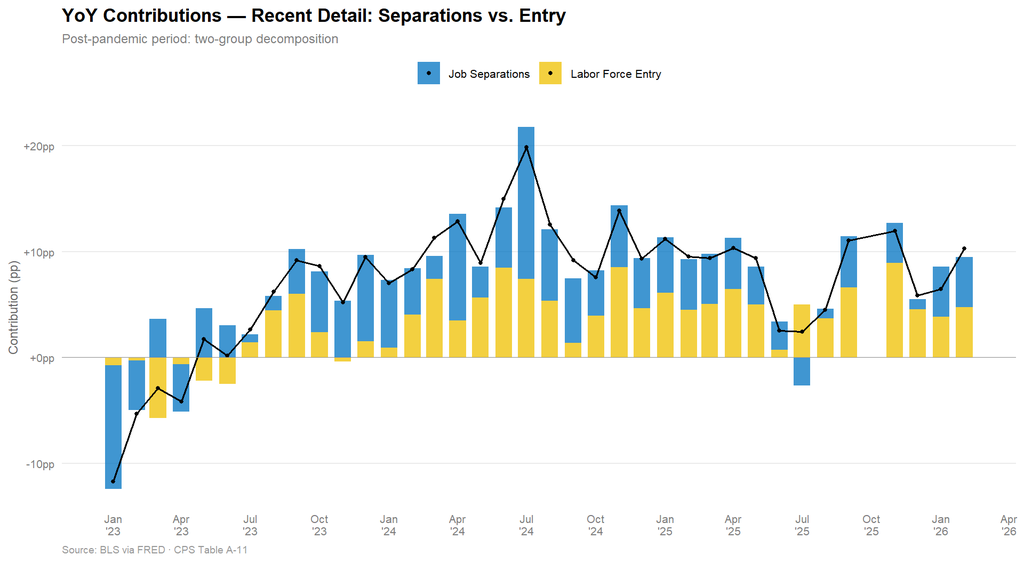

Figure 26: Year-over-year contributions zoomed to post-pandemic: separations vs. entry.

```r
df_yoy_recent2_long |>
  ggplot(aes(x = date, y = contrib, fill = group)) +
  geom_col(alpha = 0.75, width = 22) +
  geom_line(
    data = df_yoy_recent2, aes(x = date, y = total_chg, fill = NULL),
    color = "black", linewidth = 0.7
  ) +
  geom_point(
    data = df_yoy_recent2, aes(x = date, y = total_chg, fill = NULL),
    color = "black", size = 1
  ) +
  geom_hline(yintercept = 0, color = "grey60", linewidth = 0.3) +
  scale_fill_manual(values = group_cols) +
  scale_y_continuous(labels = \(x) paste0(sprintf("%+.0f", x), "pp")) +
  scale_x_date(date_breaks = "3 months", date_labels = "%b\n'%y") +
  labs(
    title = "YoY Contributions — Recent Detail: Separations vs. Entry",
    subtitle = "Post-pandemic period: two-group decomposition",
    y = "Contribution (pp)", x = NULL,
    caption = "Source: BLS via FRED · CPS Table A-11"
  )
```

Through 2022, total unemployment was still falling sharply year-over-year as pandemic-era job losses unwound. The six-way breakdown reveals which sub-categories of job loss are driving the recent inflection. The two-group view makes clear whether the driver is separations or new entry into the labor force.

## 8. MoM Contributions to Unemployment Growth (2023–Present)

```r
df_mom <- calc_contributions6(df6, lag = 1, start_date = as.Date("2023-01-01"))
df_mom_long <- df_mom |>
  select(date, ends_with("_contrib"), total_chg) |>
  pivot_longer(ends_with("_contrib"), names_to = "cause", values_to = "contrib") |>
  mutate(cause = str_remove(cause, "_contrib"), cause = factor(cause, levels = cause_order))

df_mom2 <- calc_contributions2(df2, lag = 1, start_date = as.Date("2023-01-01"))
df_mom2_long <- df_mom2 |>
  select(date, ends_with("_contrib"), total_chg) |>
  pivot_longer(ends_with("_contrib"), names_to = "group", values_to = "contrib") |>
  mutate(group = str_remove(group, "_contrib"), group = factor(group, levels = group_order))
```

**Six-Way**

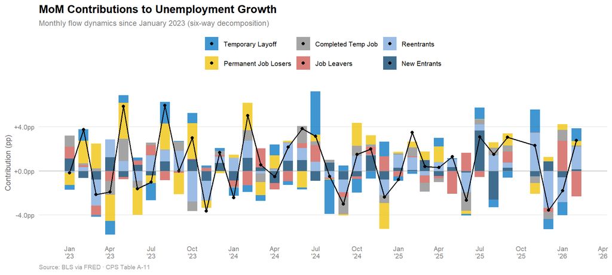

Figure 27: Month-over-month contributions to unemployment change, 2023 onward (six-way).

```r
df_mom_long |>
  ggplot(aes(x = date, y = contrib, fill = cause)) +
  geom_col(alpha = 0.75, width = 22) +
  geom_line(
    data = df_mom, aes(x = date, y = total_chg, fill = NULL),
    color = "black", linewidth = 0.7
  ) +
  geom_point(
    data = df_mom, aes(x = date, y = total_chg, fill = NULL),
    color = "black", size = 1.5
  ) +
  geom_hline(yintercept = 0, color = "grey60", linewidth = 0.3) +
  scale_fill_manual(values = cause_cols) +
  scale_y_continuous(labels = \(x) paste0(sprintf("%+.1f", x), "pp")) +
  scale_x_date(date_breaks = "3 months", date_labels = "%b\n'%y") +
  labs(
    title = "MoM Contributions to Unemployment Growth",
    subtitle = "Monthly flow dynamics since January 2023 (six-way decomposition)",
    y = "Contribution (pp)", x = NULL,
    caption = "Source: BLS via FRED · CPS Table A-11"
  )
```

**Two-Group**

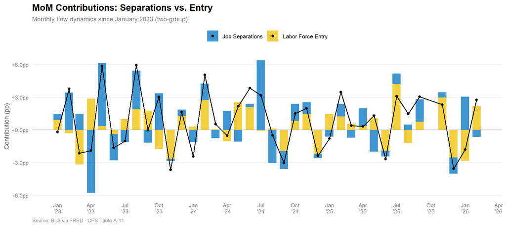

Figure 28: Month-over-month contributions: separations vs. entry, 2023 onward.

```r
df_mom2_long |>
  ggplot(aes(x = date, y = contrib, fill = group)) +
  geom_col(alpha = 0.75, width = 22) +
  geom_line(
    data = df_mom2, aes(x = date, y = total_chg, fill = NULL),
    color = "black", linewidth = 0.7
  ) +
  geom_point(
    data = df_mom2, aes(x = date, y = total_chg, fill = NULL),
    color = "black", size = 1.5
  ) +
  geom_hline(yintercept = 0, color = "grey60", linewidth = 0.3) +
  scale_fill_manual(values = group_cols) +
  scale_y_continuous(labels = \(x) paste0(sprintf("%+.1f", x), "pp")) +
  scale_x_date(date_breaks = "3 months", date_labels = "%b\n'%y") +
  labs(
    title = "MoM Contributions: Separations vs. Entry",
    subtitle = "Monthly flow dynamics since January 2023 (two-group)",
    y = "Contribution (pp)", x = NULL,
    caption = "Source: BLS via FRED · CPS Table A-11"
  )
```

Month-to-month contributions are noisy but the six-way breakdown reveals whether monthly swings are driven by temporary layoffs (often reversible) or permanent job losers (more persistent). The two-group view cleanly separates the separation and entry channels.